# Coursera:PeerGradedAssign:ML

Nikhil Tiwari

9/2/2017

# Overview

Using motion/activity sensing and recording devices such as Jawbone Up, Nike FuelBand, and Fitbit, it is now possible to collect a large amount of data about personal activity relatively inexpensively. These type of devices are part of the quantified self movement - a group of enthusiasts who take measurements about themselves regularly to improve their health, to find patterns in their behavior, or because they are tech geeks. One thing that people regularly do is quantify how much of a particular activity they do, but they rarely quantify how well they do it.

DATA: In this project, data from accelerometers on the belt, forearm, arm, and dumbell of 6 participants, has been collected. They were asked to perform barbell lifts correctly and incorrectly in 5 different ways.

AIM: The goal of this project is to build a machine learning algorithm to predict activity quality (classe) from activity monitors.

# Preliminary Work

## Reproduceability

An overall pseudo-random number generator seed was set at 1234 for all code. In order to reproduce the results below, the same seed should be used.Different packages were downloaded and installed, such as caret and randomForest. These should also be installed in order to reproduce the results below (please see code below for ways and syntax to do so).

```r
# Setting Over all Seed
set.seed(1234)
# Loading required packages
req.Packages <- c("caret", "ggplot2", "GGally", "corrplot","randomForest", "rpart", "rpart.plot")
# To check and install missing package and load them
for(item in req.Packages){
  if(!require(item,character.only = TRUE)){
    install.packages(item, dependencies = T)
  }
  library(item, character.only = TRUE, verbose = F)
}
# Creating and setting working directory
if(!dir.exists("~/Desktop/CourseraMLPA")){
dir.create("~/Desktop/CourseraMLPA")
print("Directory created successfully")
}

setwd("~/Desktop/CourseraMLPA")
print("Working Directory has been changed to ~/Desktop/CourseraMLPA")
```

```
## [1] "Working Directory has been changed to ~/Desktop/CourseraMLPA"
```

# Downloading and Reading the data from assignment page

Now we will go ahead and downlaod data from the course peer graded assignment page “https://www.coursera.org/learn/practical-machine-learning/supplement/PvInj/course-project-instructions-read-first” 1. Training Dataset from “https://d396qusza40orc.cloudfront.net/predmachlearn/pml-training.csv” 2. Testing Dataset from “https://d396qusza40orc.cloudfront.net/predmachlearn/pml-testing.csv”

```r
Tr_Url <- "https://d396qusza40orc.cloudfront.net/predmachlearn/pml-training.csv"
Tst_Url <- "https://d396qusza40orc.cloudfront.net/predmachlearn/pml-testing.csv"
# downloading Taining data and reading in r
download.file(url=Tr_Url, destfile="train.csv", method = "curl")
train <- read.csv("train.csv", na.strings = c("NA","#DIV/0!",""))
dim(train)
```

```
## [1] 19622   160
```

```r
# downloading Testing data and reading in R
download.file(url=Tst_Url, destfile="test.csv", method = "curl")
test <- read.csv("test.csv", na.strings = c("NA","#DIV/0!",""))
dim(test)
```

```
## [1]  20 160
```

```r
# Seeing Data Structure of training data and conducting basis operations
str(train)
```

```
## 'data.frame':    19622 obs. of  160 variables:
##  $ X                       : int  1 2 3 4 5 6 7 8 9 10 ...
##  $ user_name               : Factor w/ 6 levels "adelmo","carlitos",..: 2 2 2 2 2 2 2 2 2 2 ...
##  $ raw_timestamp_part_1    : int  1323084231 1323084231 1323084231 1323084232 1323084232 1323084232 1323084232 1323084232 1323084232 1323084232 ...
##  $ raw_timestamp_part_2    : int  788290 808298 820366 120339 196328 304277 368296 440390 484323 484434 ...
##  $ cvtd_timestamp          : Factor w/ 20 levels "02/12/2011 13:32",..: 9 9 9 9 9 9 9 9 9 9 ...
##  $ new_window              : Factor w/ 2 levels "no","yes": 1 1 1 1 1 1 1 1 1 1 ...
##  $ num_window              : int  11 11 11 12 12 12 12 12 12 12 ...
##  $ roll_belt               : num  1.41 1.41 1.42 1.48 1.48 1.45 1.42 1.42 1.43 1.45 ...
##  $ pitch_belt              : num  8.07 8.07 8.07 8.05 8.07 8.06 8.09 8.13 8.16 8.17 ...
##  $ yaw_belt                : num  -94.4 -94.4 -94.4 -94.4 -94.4 -94.4 -94.4 -94.4 -94.4 -94.4 ...
##  $ total_accel_belt        : int  3 3 3 3 3 3 3 3 3 3 ...
##  $ kurtosis_roll_belt      : num  NA NA NA NA NA NA NA NA NA NA ...
##  $ kurtosis_picth_belt     : num  NA NA NA NA NA NA NA NA NA NA ...
##  $ kurtosis_yaw_belt       : logi  NA NA NA NA NA NA ...
```

[output cut: 86 more lines]

```r
View(train)
summary(train)
```

```
##        X            user_name    raw_timestamp_part_1 raw_timestamp_part_2
##  Min.   :    1   adelmo  :3892   Min.   :1.322e+09    Min.   :   294
##  1st Qu.: 4906   carlitos:3112   1st Qu.:1.323e+09    1st Qu.:252912
##  Median : 9812   charles :3536   Median :1.323e+09    Median :496380
##  Mean   : 9812   eurico  :3070   Mean   :1.323e+09    Mean   :500656
##  3rd Qu.:14717   jeremy  :3402   3rd Qu.:1.323e+09    3rd Qu.:751891
##  Max.   :19622   pedro   :2610   Max.   :1.323e+09    Max.   :998801
##
##           cvtd_timestamp  new_window    num_window      roll_belt
##  28/11/2011 14:14: 1498   no :19216   Min.   :  1.0   Min.   :-28.90
##  05/12/2011 11:24: 1497   yes:  406   1st Qu.:222.0   1st Qu.:  1.10
##  30/11/2011 17:11: 1440               Median :424.0   Median :113.00
##  05/12/2011 11:25: 1425               Mean   :430.6   Mean   : 64.41
##  02/12/2011 14:57: 1380               3rd Qu.:644.0   3rd Qu.:123.00
##  02/12/2011 13:34: 1375               Max.   :864.0   Max.   :162.00
##  (Other)         :11007
##    pitch_belt          yaw_belt       total_accel_belt kurtosis_roll_belt
##  Min.   :-55.8000   Min.   :-180.00   Min.   : 0.00    Min.   :-2.121
##  1st Qu.:  1.7600   1st Qu.: -88.30   1st Qu.: 3.00    1st Qu.:-1.329
##  Median :  5.2800   Median : -13.00   Median :17.00    Median :-0.899
##  Mean   :  0.3053   Mean   : -11.21   Mean   :11.31    Mean   :-0.220
##  3rd Qu.: 14.9000   3rd Qu.:  12.90   3rd Qu.:18.00    3rd Qu.:-0.219
##  Max.   : 60.3000   Max.   : 179.00   Max.   :29.00    Max.   :33.000
##                                                        NA's   :19226
##  kurtosis_picth_belt kurtosis_yaw_belt skewness_roll_belt
##  Min.   :-2.190      Mode:logical      Min.   :-5.745
##  1st Qu.:-1.107      NA's:19622        1st Qu.:-0.444
##  Median :-0.151                        Median : 0.000
##  Mean   : 4.334                        Mean   :-0.026
##  3rd Qu.: 3.178                        3rd Qu.: 0.417
##  Max.   :58.000                        Max.   : 3.595
##  NA's   :19248                         NA's   :19225
##  skewness_roll_belt.1 skewness_yaw_belt max_roll_belt     max_picth_belt
##  Min.   :-7.616       Mode:logical      Min.   :-94.300   Min.   : 3.00
##  1st Qu.:-1.114       NA's:19622        1st Qu.:-88.000   1st Qu.: 5.00
##  Median :-0.068                         Median : -5.100   Median :18.00
##  Mean   :-0.296                         Mean   : -6.667   Mean   :12.92
##  3rd Qu.: 0.661                         3rd Qu.: 18.500   3rd Qu.:19.00
##  Max.   : 7.348                         Max.   :180.000   Max.   :30.00
##  NA's   :19248                          NA's   :19216     NA's   :19216
```

[output cut: 313 more lines]

```
##  Min.   :-446.00   Min.   :-1280.0   Min.   :-896.0   Min.   :-973.0
##  1st Qu.:-182.00   1st Qu.: -616.0   1st Qu.:   2.0   1st Qu.: 191.0
##  Median : -39.00   Median : -378.0   Median : 591.0   Median : 511.0
##  Mean   : -55.29   Mean   : -312.6   Mean   : 380.1   Mean   : 393.6
##  3rd Qu.:  26.00   3rd Qu.:  -73.0   3rd Qu.: 737.0   3rd Qu.: 653.0
##  Max.   : 291.00   Max.   :  672.0   Max.   :1480.0   Max.   :1090.0
##
##  classe
##  A:5580
##  B:3797
##  C:3422
##  D:3216
##  E:3607
##
##
```

# Data Cleaning: Fixing missing values

```r
train<-train[,colSums(is.na(train)) == 0]
dim(train)
```

```
## [1] 19622    60
```

```r
View(train)
#summary of outcome we want to predict
summary(train$classe)
```

```
##    A    B    C    D    E
## 5580 3797 3422 3216 3607
```

```r
# Some variables are irrelevant to our current project: user_name, raw_timestamp_part_1, raw_timestamp_part_,2 cvtd_timestamp, new_window, and  num_window (columns 1 to 7). We can delete these variables.
#removing columns which are not predictors
train <- train[,-c(1:7)]

# Similarly for testing set
test <-test[,colSums(is.na(test)) == 0]
dim(test)
```

```
## [1] 20 60
```

```r
View(test)
test <- test[,-c(1:7)]
```

# Split training data into Training and Validation sets

For our calculation, we will set aside a subset of our training data for cross validation (30%).

```r
inTrain <- createDataPartition(y=train$classe, p=0.7, list=FALSE)
train_final <- train[inTrain, ]
valid <- train[-inTrain, ]
dim(train_final)
```

```
## [1] 13737    53
```

```r
dim(valid)
```

```
## [1] 5885   53
```

# Exploratory Analysis just to spot some trend or anamoly

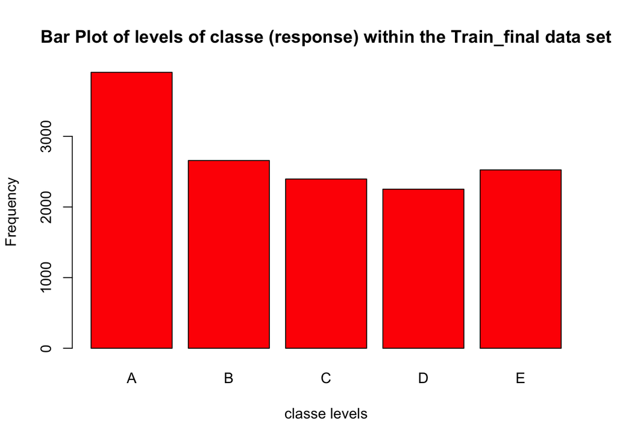

```r
# A look at the response Data

## The response variable “classe” contains 5 levels: A, B, C, D and E. By observing this plot will can assess the frequency of each levels in the subTraining data set and compare one another.

plot(train_final$classe, col="red", main="Bar Plot of levels of classe (response) within the Train_final data set", xlab="classe levels", ylab="Frequency")
```

```r
corrtab <- cor(train_final[,-53])
corrtab
```

[output not shown]

[output cut: 846 more lines]

```
## magnet_dumbbell_y        -0.043304583
## magnet_dumbbell_z        -0.583714736
## roll_forearm              0.401734226
## pitch_forearm            -0.014814727
## yaw_forearm               0.063049954
## total_accel_forearm      -0.013330626
## gyros_forearm_x           0.172472262
## gyros_forearm_y           0.064192782
## gyros_forearm_z           0.002526356
## accel_forearm_x           0.063935898
## accel_forearm_y           0.282029476
## accel_forearm_z          -0.547094277
## magnet_forearm_x         -0.131200896
## magnet_forearm_y          0.240553118
## magnet_forearm_z          1.000000000
```

[figure not shown]

```r
featurePlot(x=train_final[,42:53], y = train$classe, plot = 'pairs')
```

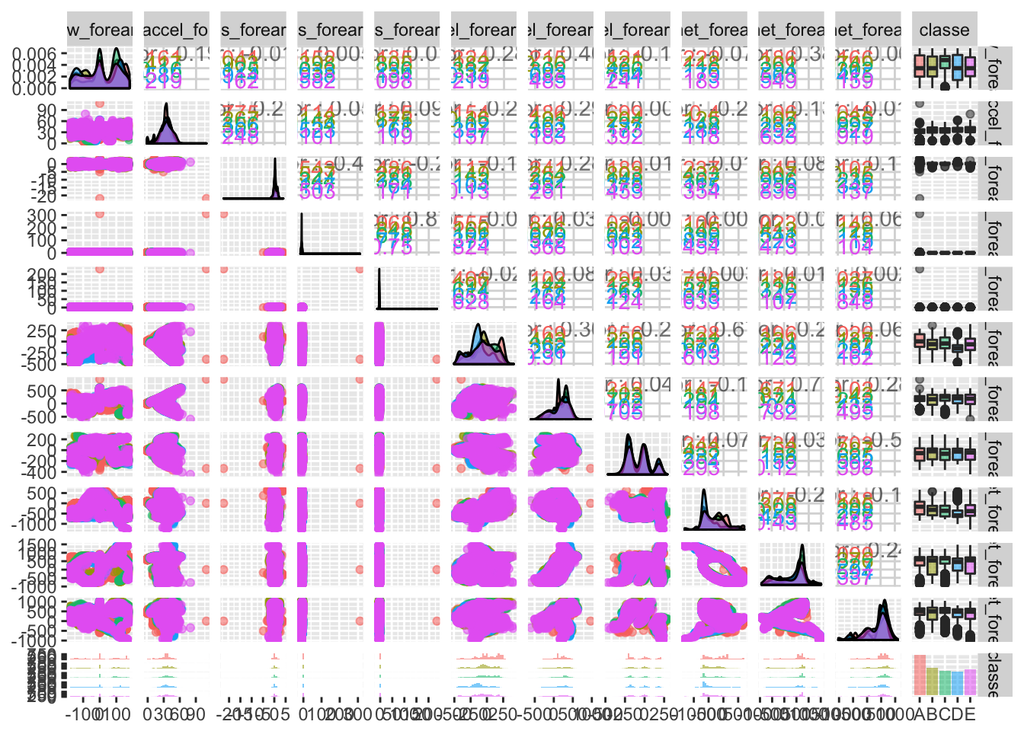

```r
g = ggpairs(train_final[,42:53], aes(color = classe, alpha = 0.4))
g
```

# Model Creation approach

we will be using decision tree and random forest models as the reponse variable has many levels. Since, our outcome variable is classe, a factor variable with 5 levels. For this data set, “participants were asked to perform one set of 10 repetitions of the Unilateral Dumbbell Biceps Curl in 5 different fashions: - exactly according to the specification (Class A) - throwing the elbows to the front (Class B) - lifting the dumbbell only halfway (Class C) - lowering the dumbbell only halfway (Class D) - throwing the hips to the front (Class E)

Class A corresponds to the excercise execution based on specifications (ideal), while the other 4 classes represent correspond common mistakes.Prediction evaluations will be based on maximizing the accuracy and minimizing the out-of-sample error. All other available variables after cleaning will be used in our analysis for prediction.

we will be desiging two models using decision tree and random forest algorithms and later will be tested for accuracy. The model with the highest accuracy will be chosen as our final model.

# Modeling decison Tree using Rpart

```r
# Decision Tree
model1 <- rpart(classe ~ ., train_final, method="class")
summary(model1)
```

```
## Call:
## rpart(formula = classe ~ ., data = train_final, method = "class")
##   n= 13737
##
##            CP nsplit rel error    xerror        xstd
## 1  0.11738379      0 1.0000000 1.0000000 0.005378006
## 2  0.06092971      1 0.8826162 0.8830231 0.005749694
## 3  0.03549995      4 0.6998271 0.7580104 0.005939439
## 4  0.03173634      5 0.6643271 0.6564948 0.005950124
## 5  0.02319194      6 0.6325908 0.6317770 0.005933613
## 6  0.02064897     11 0.5104262 0.5439935 0.005813091
## 7  0.01851287     12 0.4897772 0.5053403 0.005728253
## 8  0.01800427     13 0.4712644 0.4931340 0.005697235
## 9  0.01352863     14 0.4532601 0.4514292 0.005575299
## 10 0.01342691     15 0.4397315 0.4272200 0.005492713
## 11 0.01129081     16 0.4263045 0.4178619 0.005458360
## 12 0.01000000     17 0.4150137 0.3880582 0.005339533
##
## Variable importance
##            roll_belt         accel_belt_z           pitch_belt
##                   14                    7                    7
##        pitch_forearm     total_accel_belt         roll_forearm
##                    6                    5                    5
## total_accel_dumbbell     accel_dumbbell_y    magnet_dumbbell_y
##                    5                    5                    5
##        magnet_belt_z      accel_forearm_x             yaw_belt
##                    4                    4                    3
##        roll_dumbbell    magnet_dumbbell_z         accel_belt_y
##                    3                    3                    3
##     accel_dumbbell_x        magnet_belt_x         accel_belt_x
##                    2                    2                    2
##        magnet_belt_y     magnet_forearm_z     magnet_forearm_x
##                    2                    2                    2
##     magnet_forearm_y      accel_forearm_z     accel_dumbbell_z
##                    2                    1                    1
##          yaw_forearm  total_accel_forearm              yaw_arm
##                    1                    1                    1
##    magnet_dumbbell_x         yaw_dumbbell
##                    1                    1
##
```

[output cut: 379 more lines]

```
##
## Node number 669: 1964 observations
##   predicted class=D  expected loss=0.610998  P(node) =0.1429715
##     class counts:   374   294   267   764   265
##    probabilities: 0.190 0.150 0.136 0.389 0.135
##
## Node number 1336: 193 observations
##   predicted class=A  expected loss=0.03108808  P(node) =0.01404965
##     class counts:   187     0     5     0     1
##    probabilities: 0.969 0.000 0.026 0.000 0.005
##
## Node number 1337: 444 observations
##   predicted class=C  expected loss=0.1351351  P(node) =0.03232147
##     class counts:    30    21   384     9     0
##    probabilities: 0.068 0.047 0.865 0.020 0.000
```

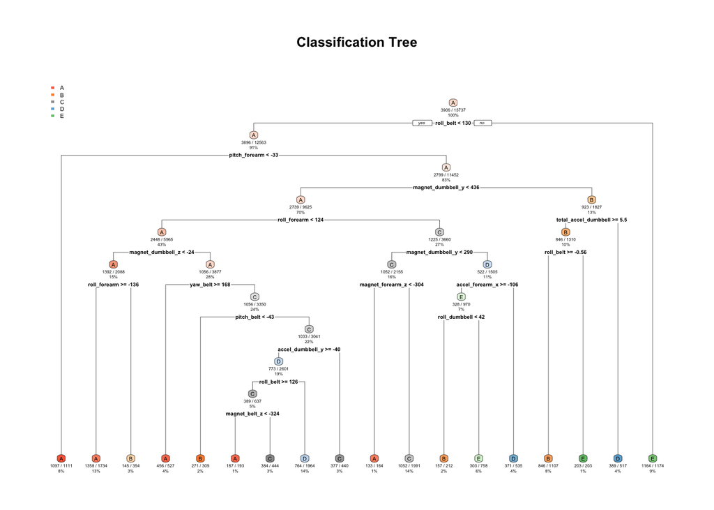

```r
# Plot of the Decision Tree
rpart.plot(model1, main="Classification Tree", extra=102, under=TRUE, faclen=0)
```

```r
# Predicting:
prediction1 <- predict(model1, valid[,-53], type = "class")
```

# Modeling using Random Forest

```r
# Random Forest
model2 <- randomForest(classe ~. , data= train_final, method="class")
summary(model2)
```

```
##                 Length Class  Mode
## call                4  -none- call
## type                1  -none- character
## predicted       13737  factor numeric
## err.rate         3000  -none- numeric
## confusion          30  -none- numeric
## votes           68685  matrix numeric
## oob.times       13737  -none- numeric
## classes             5  -none- character
## importance         52  -none- numeric
## importanceSD        0  -none- NULL
## localImportance     0  -none- NULL
## proximity           0  -none- NULL
## ntree               1  -none- numeric
## mtry                1  -none- numeric
## forest             14  -none- list
## y               13737  factor numeric
## test                0  -none- NULL
## inbag               0  -none- NULL
## terms               3  terms  call
```

```r
print(model2)
```

```
##
## Call:
##  randomForest(formula = classe ~ ., data = train_final, method = "class")
##                Type of random forest: classification
##                      Number of trees: 500
## No. of variables tried at each split: 7
##
##         OOB estimate of  error rate: 0.51%
## Confusion matrix:
##      A    B    C    D    E class.error
## A 3902    3    0    0    1 0.001024066
## B   14 2640    4    0    0 0.006772009
## C    0   13 2380    3    0 0.006677796
## D    0    0   23 2227    2 0.011101243
## E    0    0    1    6 2518 0.002772277
```

```r
# Predicting:
prediction2 <- predict(model2, valid[,-53], type = "class")
```

# Comparing the output of models and respective accuracy

```r
# Decision Tree output
out1 <- confusionMatrix(prediction1, valid[,53])
print(out1)
```

```
## Confusion Matrix and Statistics
##
##           Reference
## Prediction    A    B    C    D    E
##          A 1364  169   24   48   16
##          B   60  581   46   79   74
##          C   52  137  765  129  145
##          D  183  194  125  650  159
##          E   15   58   66   58  688
##
## Overall Statistics
##
##                Accuracy : 0.6879
##                  95% CI : (0.6758, 0.6997)
##     No Information Rate : 0.2845
##     P-Value [Acc > NIR] : < 2.2e-16
##
##                   Kappa : 0.6066
##  Mcnemar's Test P-Value : < 2.2e-16
##
## Statistics by Class:
##
##                      Class: A Class: B Class: C Class: D Class: E
## Sensitivity            0.8148  0.51010   0.7456   0.6743   0.6359
## Specificity            0.9390  0.94543   0.9047   0.8657   0.9590
## Pos Pred Value         0.8415  0.69167   0.6230   0.4958   0.7774
## Neg Pred Value         0.9273  0.88940   0.9440   0.9314   0.9212
## Prevalence             0.2845  0.19354   0.1743   0.1638   0.1839
## Detection Rate         0.2318  0.09873   0.1300   0.1105   0.1169
## Detection Prevalence   0.2754  0.14274   0.2087   0.2228   0.1504
## Balanced Accuracy      0.8769  0.72776   0.8252   0.7700   0.7974
```

```r
out1$overall
```

```
##       Accuracy          Kappa  AccuracyLower  AccuracyUpper   AccuracyNull
##   6.878505e-01   6.066189e-01   6.758358e-01   6.996786e-01   2.844520e-01
## AccuracyPValue  McnemarPValue
##   0.000000e+00   2.264771e-61
```

```r
# Random forest output
out2 <- confusionMatrix(prediction2, valid[,53])
print(out2)
```

```
## Confusion Matrix and Statistics
##
##           Reference
## Prediction    A    B    C    D    E
##          A 1674    5    0    0    0
##          B    0 1133    6    0    0
##          C    0    1 1020    4    0
##          D    0    0    0  959    1
##          E    0    0    0    1 1081
##
## Overall Statistics
##
##                Accuracy : 0.9969
##                  95% CI : (0.9952, 0.9982)
##     No Information Rate : 0.2845
##     P-Value [Acc > NIR] : < 2.2e-16
##
##                   Kappa : 0.9961
##  Mcnemar's Test P-Value : NA
##
## Statistics by Class:
##
##                      Class: A Class: B Class: C Class: D Class: E
## Sensitivity            1.0000   0.9947   0.9942   0.9948   0.9991
## Specificity            0.9988   0.9987   0.9990   0.9998   0.9998
## Pos Pred Value         0.9970   0.9947   0.9951   0.9990   0.9991
## Neg Pred Value         1.0000   0.9987   0.9988   0.9990   0.9998
## Prevalence             0.2845   0.1935   0.1743   0.1638   0.1839
## Detection Rate         0.2845   0.1925   0.1733   0.1630   0.1837
## Detection Prevalence   0.2853   0.1935   0.1742   0.1631   0.1839
## Balanced Accuracy      0.9994   0.9967   0.9966   0.9973   0.9994
```

```r
out2$overall
```

```
##       Accuracy          Kappa  AccuracyLower  AccuracyUpper   AccuracyNull
##      0.9969414      0.9961308      0.9951703      0.9981863      0.2844520
## AccuracyPValue  McnemarPValue
##      0.0000000            NaN
```

```r
# disabling scientific notation for comparision or results
options(scipen = 999)

## comparing over all result of both the models
out1$overall
```

```
##                                                              Accuracy
## 0.6878504672897196581260459424811415374279022216796875000000000000000
##                                                                 Kappa
## 0.6066189210391574881953147269086912274360656738281250000000000000000
##                                                         AccuracyLower
## 0.6758358483862271226527695944241713732481002807617187500000000000000
##                                                         AccuracyUpper
## 0.6996786049450577360531156045908574014902114868164062500000000000000
##                                                          AccuracyNull
## 0.2844519966015293110928041642182506620883941650390625000000000000000
##                                                        AccuracyPValue
## 0.0000000000000000000000000000000000000000000000000000000000000000000
##                                                         McnemarPValue
## 0.0000000000000000000000000000000000000000000000000000000000002264771
```

```r
out2$overall
```

```
##       Accuracy          Kappa  AccuracyLower  AccuracyUpper   AccuracyNull
##      0.9969414      0.9961308      0.9951703      0.9981863      0.2844520
## AccuracyPValue  McnemarPValue
##      0.0000000            NaN
```

```r
rbind(out1$overall, out2$overall)
```

```
##       Accuracy     Kappa AccuracyLower AccuracyUpper AccuracyNull
## [1,] 0.6878505 0.6066189     0.6758358     0.6996786     0.284452
## [2,] 0.9969414 0.9961308     0.9951703     0.9981863     0.284452
##      AccuracyPValue
## [1,]              0
## [2,]              0
##                                                              McnemarPValue
## [1,] 0.0000000000000000000000000000000000000000000000000000000000002264771
## [2,]                                                                   NaN
```

# Decision on model and errors

Upon comparision of both the models its clearly evident that Random Forest yield a more accurate model. So for final prediction we will be using random forest model.

# Final Predictions

```r
final_predict <- predict(model2, test[,-53], type = "class")
print(final_predict)
```

```
##  1  2  3  4  5  6  7  8  9 10 11 12 13 14 15 16 17 18 19 20
##  B  A  B  A  A  E  D  B  A  A  B  C  B  A  E  E  A  B  B  B
## Levels: A B C D E
```

```r
Result <- cbind(test, final_predict)
View(Result)
write.csv(Result, "Final Predictions.csv")
```